# Notes on Chapter 25 - Functions

Norman Lim

2025-08-15

### Prerequisites

```r
library(tidyverse)
library(nycflights13)
```

## Vector functions

Vector functions are functions that take one or more vectors and return a vector result.

Example:

```r
df <- tibble(
  a = rnorm(5),
  b = rnorm(5),
  c = rnorm(5),
  d = rnorm(5),
)

df |> mutate(
  a = (a - min(a, na.rm = TRUE)) / (max(a, na.rm = TRUE) - min(a, na.rm = TRUE)),
  b = (b - min(a, na.rm = TRUE)) / (max(b, na.rm = TRUE) - min(b, na.rm = TRUE)),
  c = (c - min(c, na.rm = TRUE)) / (max(c, na.rm = TRUE) - min(c, na.rm = TRUE)),
  d = (d - min(d, na.rm = TRUE)) / (max(d, na.rm = TRUE) - min(d, na.rm = TRUE))
)
```

```
## # A tibble: 5 × 4
##       a      b     c     d
##   <dbl>  <dbl> <dbl> <dbl>
## 1 0.467  0.291 0.525 0.802
## 2 0.229  0.224 0     0
## 3 0.462  0.141 0.193 1
## 4 1      0.844 0.774 0.903
## 5 0     -0.156 1     0.157
```

There is a mistake in `b`. This could have been avoided if we used functions.

Three things needed to make a function:  
- A **name**.  
- The **arguments**.  
- The **body**.

Format:

```r
name <- function(x) {
  body
}
```

Creating the function for the rescaling code above:

```r
rescale01 <- function(x) {
  (x - min(x, na.rm = TRUE)) / (max(x, na.rm = TRUE) - min(x, na.rm = TRUE))
}
```

Testing if the function works as intended:

```r
rescale01(c(-10, 0, 10))
```

```
## [1] 0.0 0.5 1.0
```

```r
rescale01(c(1, 2, 3, NA, 5))
```

```
## [1] 0.00 0.25 0.50   NA 1.00
```

Using the function (or calling the function):

```r
df |> mutate(
  a = rescale01(a),
  b = rescale01(b),
  c = rescale01(c),
  d = rescale01(d)
)
```

```
## # A tibble: 5 × 4
##       a     b     c     d
##   <dbl> <dbl> <dbl> <dbl>
## 1 0.467 0.447 0.525 0.802
## 2 0.229 0.380 0     0
## 3 0.462 0.297 0.193 1
## 4 1     1     0.774 0.903
## 5 0     0     1     0.157
```

### Improving the function

Replacing the repetitious parts of the function:

```r
rescale01 <- function(x) {
  rng <- range(x, na.rm = TRUE)
  (x - rng[1]) / (rng[2] - rng[1])
}
```

Retesting:

```r
x <- c(1:10,Inf)
rescale01(x)
```

```
##  [1]   0   0   0   0   0   0   0   0   0   0 NaN
```

The result is not particularly useful. It is better to ignore infinite values:

```r
rescale01 <- function(x) {
  rng <- range(x, na.rm = TRUE, finite = TRUE)
  (x - rng[1]) / (rng[2] - rng[1])
}
```

Retesting:

```r
rescale01(x)
```

```
##  [1] 0.0000000 0.1111111 0.2222222 0.3333333 0.4444444 0.5555556 0.6666667
##  [8] 0.7777778 0.8888889 1.0000000       Inf
```

### Mutate functions

A simple variation of `rescale01`:

```r
z_score <- function(x) {
  (x - mean(x, na.rm = TRUE)) / sd(x, na.rm = TRUE)
}
```

Another variation using `case_when()`:

```r
clamp <- function(x, min, max) {
  case_when(
    x < min ~ min,
    x > max ~ max,
    .default = x
  )
}

clamp(1:10, min = 3, max = 7)
```

```
##  [1] 3 3 3 4 5 6 7 7 7 7
```

A function that makes the first character upper case:

```r
first_upper <- function(x) {
  str_sub(x, 1, 1) <- str_to_upper(str_sub(x, 1, 1))
  x
}

first_upper("hello")
```

```
## [1] "Hello"
```

A function for stripping percent signs:

```r
# https://twitter.com/NVlabormarket/status/1571939851922198530
clean_number <- function(x) {
  is_pct <- str_detect(x, "%")
  num <- x |>
    str_remove_all("%") |>
    str_remove_all(",") |>
    str_remove_all(fixed("$")) |>
    as.numeric()
  if_else(is_pct, num / 100, num)
}

clean_number("$12,300")
```

```
## [1] 12300
```

```r
clean_number("45%")
```

```
## [1] 0.45
```

A function for replacing 997, 998, or 999 with `NA`:

```r
fix_na <- function(x) {
  if_else(x %in% c(997, 998, 999), NA, x)
}
```

### Summary functions

These are functions that return a single value for use in `summarize()`.

Example:

```r
commas <- function(x) {
  str_flatten(x, collapse = ", ", last = " and ")
}

commas(c("cat", "dog", "pigeon"))
```

```
## [1] "cat, dog and pigeon"
```

Another example with mathematical computation – coefficient of variation:

```r
cv <- function(x, na.rm = FALSE) {
  sd(x, na.rm = na.rm) / mean(x, na.rm = na.rm)
}

cv(runif(100, min = 0, max = 50))
```

```
## [1] 0.5919366
```

```r
cv(runif(100, min = 0, max = 500))
```

```
## [1] 0.5958879
```

An example for making handling missing data more “readable”:

```r
n_missing <- function(x) {
  sum(is.na(x))
}
```

Another example with multiple vector inputs:

```r
mape <- function(actual, predicted) {
  sum(abs((actual - predicted) / actual)) / length(actual)
}
```

## Data frame functions

Embracing (wrapping a variable in double braces) to tell dplyr to use the value stored inside the argument:

```r
grouped_mean <- function(df, group_var, mean_var) {
  df |>
    group_by({{ group_var }}) |>
    summarize(mean({{ mean_var }}))
}

df <- tibble(
  mean_var = 1,
  group_var = "g",
  group = 1,
  x = 10,
  y = 100
)

df |> grouped_mean(group, x)
```

```
## # A tibble: 1 × 2
##   group `mean(x)`
##   <dbl>     <dbl>
## 1     1        10
```

Without embracing, the function above will throw an error. This problem happens because dplyr uses **tidy evaluation** to allow referring to the names of variables inside the data frame without any special treatment.

### When to use embracing?

- **Data-masking:** used in functions like `arrange()`, `filter()`, and `summarize()` that compute with variables.
- **Tidy-selection:** used for functions like `select()`, `relocate()`, and `rename()` that select variables.

### Common use cases of embracing

```r
summary6 <- function(data, var) {
  data |> summarize(
    min = min({{ var }}, na.rm = TRUE),
    mean = mean({{ var }}, na.rm = TRUE),
    median = median({{ var }}, na.rm = TRUE),
    max = max({{ var }}, na.rm = TRUE),
    n = n(),
    n_miss = sum(is.na({{ var }})),
    .groups = "drop"
  )
}

diamonds |> summary6(carat)
```

```
## # A tibble: 1 × 6
##     min  mean median   max     n n_miss
##   <dbl> <dbl>  <dbl> <dbl> <int>  <int>
## 1   0.2 0.798    0.7  5.01 53940      0
```

**Tip:** Whenever you wrap `summarize()` in a helper, it is a good idea to set `.groups = "drop"` to both avoid seeing the warning and leaving the data in an ungrouped state.

Example using the function above on grouped data:

```r
diamonds |>
  group_by(cut) |>
  summary6(carat)
```

```
## # A tibble: 5 × 7
##   cut         min  mean median   max     n n_miss
##   <ord>     <dbl> <dbl>  <dbl> <dbl> <int>  <int>
## 1 Fair       0.22 1.05    1     5.01  1610      0
## 2 Good       0.23 0.849   0.82  3.01  4906      0
## 3 Very Good  0.2  0.806   0.71  4    12082      0
## 4 Premium    0.2  0.892   0.86  4.01 13791      0
## 5 Ideal      0.2  0.703   0.54  3.5  21551      0
```

Example using the function above on computed variables:

```r
diamonds |>
  group_by(cut) |>
  summary6(log10(carat))
```

```
## # A tibble: 5 × 7
##   cut          min    mean  median   max     n n_miss
##   <ord>      <dbl>   <dbl>   <dbl> <dbl> <int>  <int>
## 1 Fair      -0.658 -0.0273  0      0.700  1610      0
## 2 Good      -0.638 -0.133  -0.0862 0.479  4906      0
## 3 Very Good -0.699 -0.164  -0.149  0.602 12082      0
## 4 Premium   -0.699 -0.125  -0.0655 0.603 13791      0
## 5 Ideal     -0.699 -0.225  -0.268  0.544 21551      0
```

Example using the helper function `count()` to compute proportions:

```r
count_prop <- function(df, var, sort = FALSE) {
  df |>
    count({{ var }}, sort = sort) |>
    mutate(prop = n / sum(n))
}

diamonds |> count_prop(clarity)
```

```
## # A tibble: 8 × 3
##   clarity     n   prop
##   <ord>   <int>  <dbl>
## 1 I1        741 0.0137
## 2 SI2      9194 0.170
## 3 SI1     13065 0.242
## 4 VS2     12258 0.227
## 5 VS1      8171 0.151
## 6 VVS2     5066 0.0939
## 7 VVS1     3655 0.0678
## 8 IF       1790 0.0332
```

Example with conditional variables as input argument:

```r
unique_where <- function(df, condition, var) {
  df |>
    filter({{ condition }}) |>
    distinct({{ var }}) |>
    arrange({{ var}})
}

# Find all the destinations in December
flights |> unique_where(month == 12, dest)
```

```
## # A tibble: 96 × 1
##    dest
##    <chr>
##  1 ABQ
##  2 ALB
##  3 ATL
##  4 AUS
##  5 AVL
##  6 BDL
##  7 BGR
##  8 BHM
##  9 BNA
## 10 BOS
## # ℹ 86 more rows
```

Example of a function that automatically selects a predefined set of columns (aka features):

```r
subset_flights <- function(rows, cols) {
  flights |>
    filter({{ rows }}) |>
    select(time_hour, carrier, flight, {{ cols }})
}
```

### Data-masking vs. tidy-selection

Using the `pick()` function to make tidy-selection work inside a data-masking function:

```r
count_missing <- function(df, group_vars, x_var) {
  df |>
    group_by(pick({{ group_vars }})) |>
    summarize(
      n_miss = sum(is.na({{ x_var}})),
      .groups = "drop"
    )
}

flights |>
  count_missing(c(year, month, day), dep_time)
```

```
## # A tibble: 365 × 4
##     year month   day n_miss
##    <int> <int> <int>  <int>
##  1  2013     1     1      4
##  2  2013     1     2      8
##  3  2013     1     3     10
##  4  2013     1     4      6
##  5  2013     1     5      3
##  6  2013     1     6      1
##  7  2013     1     7      3
##  8  2013     1     8      4
##  9  2013     1     9      5
## 10  2013     1    10      3
## # ℹ 355 more rows
```

Example using `pick()` to make 2d table of columns:

```r
count_wide <- function(data, rows, cols) {
  data |>
    count(pick({{ rows }}, {{ cols }})) |>
    pivot_wider(
      names_from = {{ cols }},
      values_from = n,
      names_sort = TRUE,
      values_fill = 0
    )
}

diamonds |> count_wide(c(clarity, color), cut)
```

```
## # A tibble: 56 × 7
##    clarity color  Fair  Good `Very Good` Premium Ideal
##    <ord>   <ord> <int> <int>       <int>   <int> <int>
##  1 I1      D         4     8           5      12    13
##  2 I1      E         9    23          22      30    18
##  3 I1      F        35    19          13      34    42
##  4 I1      G        53    19          16      46    16
##  5 I1      H        52    14          12      46    38
##  6 I1      I        34     9           8      24    17
##  7 I1      J        23     4           8      13     2
##  8 SI2     D        56   223         314     421   356
##  9 SI2     E        78   202         445     519   469
## 10 SI2     F        89   201         343     523   453
## # ℹ 46 more rows
```

### Exercises

1. Using the datasets from `nycflights13, write a function that:
> 1. Finds all flights that were cancelled.
> 2. Counts the number of cancelled flights and the number of flights delayed by more than an hour.
> 3. Finds all flights that were cancelled or delayed by more than a user-supplied number of hours.
> 4. Summarizes the weather to compute the minimum, mean, and maximum, of a user-supplied variable:
> 5. Converts the user-supplied variable that uses clock time (e.g. `dep_time`, `arr_time`, etc.) into a decimal time (i.e. `hours` + (`minutes`/60)).
2. For each of the following functions, list all arguments that use tidy evaluation and describe whether they use data-masking or tidy-selection: `distinct()`, `count()`, `group_by()`, `rename_width()`, `slice_min()`, `slice_sample()`.
3. Generalize the following function so that you can supply any number of variables to count.

```r
count_prop <- function(df, var, sort = FALSE) {
  df |>
    count({{ var }}, sort = sort) |>
    mutate(prop = n / sum(n))
}
```

## Plot functions

Instead of returning a value or a data frame, these functions return a plot. This works because `aes()` is a data-masking function.

Example: Imagine if you need to make a lot histograms like this:

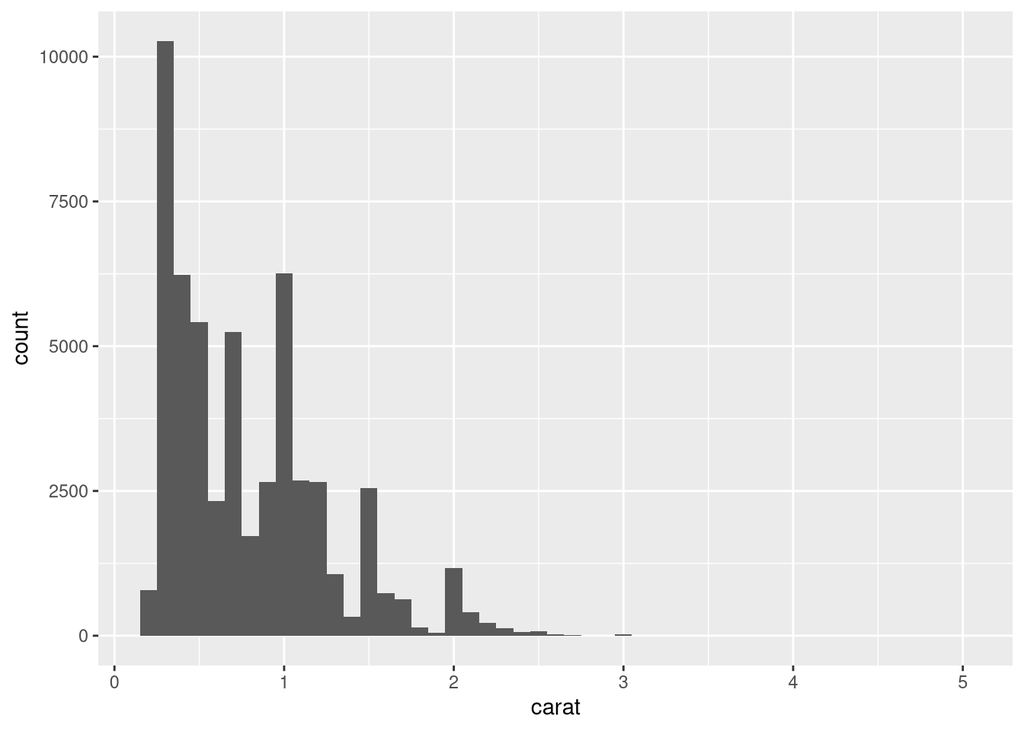

```r
diamonds |>
  ggplot(aes(x = carat)) +
  geom_histogram(binwidth = 0.1)
```

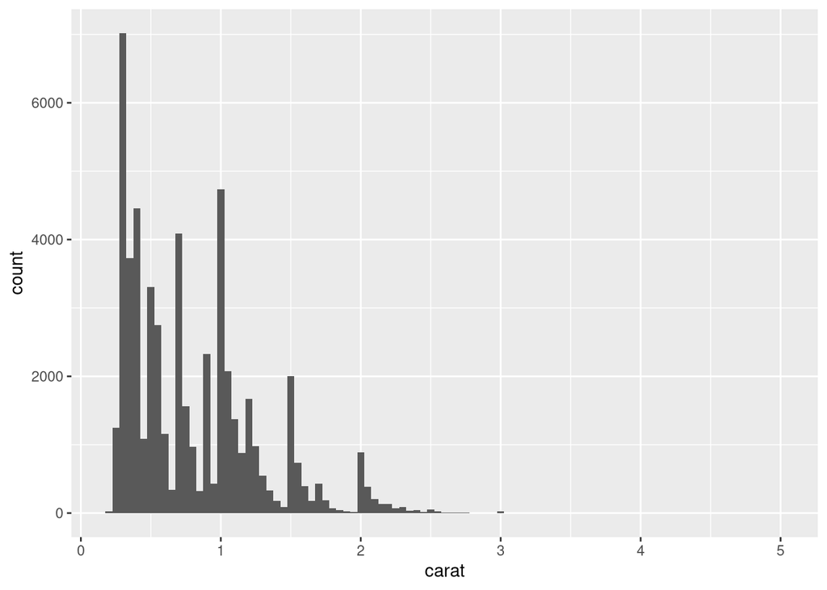

```r
diamonds |>
  ggplot(aes(x = carat)) +
  geom_histogram(binwidth = 0.05)
```

Using a function to generate the plots above (embracing is used because `aes()` is a data-masking function!):

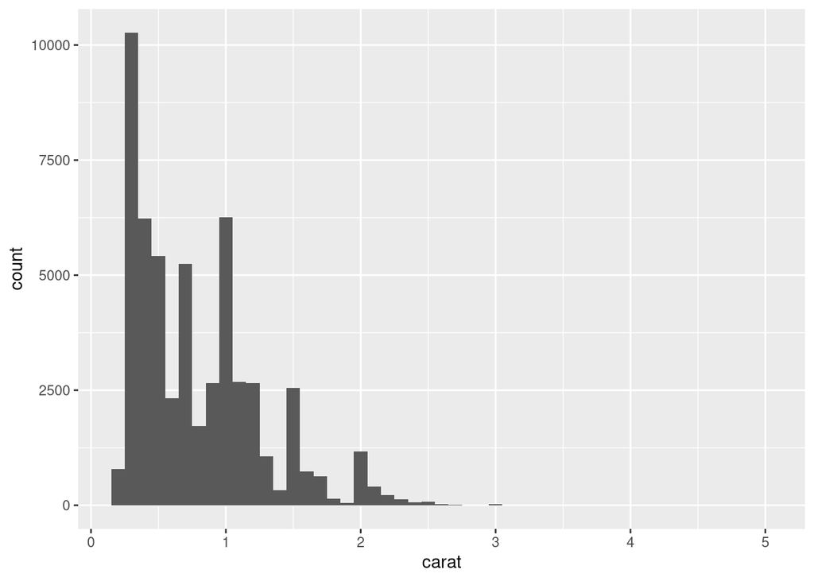

```r
histogram <- function(df, var, binwidth = NULL) {
  df |>
    ggplot(aes(x = {{ var }})) +
    geom_histogram(binwidth = binwidth)
}

diamonds |> histogram(carat, 0.1)
```

The function above generates a `ggplot2` plot so additional components can be layered, just like in other plots:

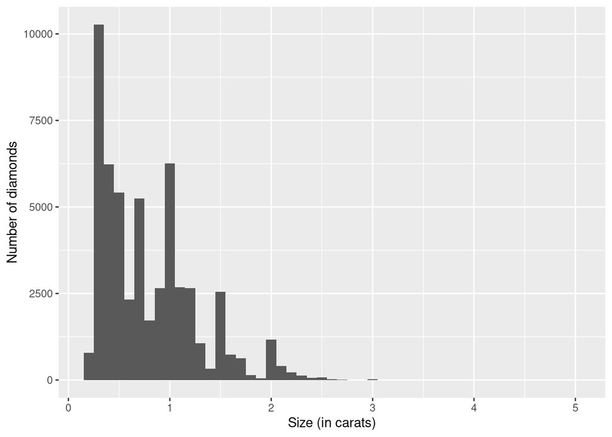

```r
diamonds |>
  histogram(carat, 0.1) +
  labs(
    x = "Size (in carats)",
    y = "Number of diamonds"
  )
```

### More variables

Example with overlaid plots:

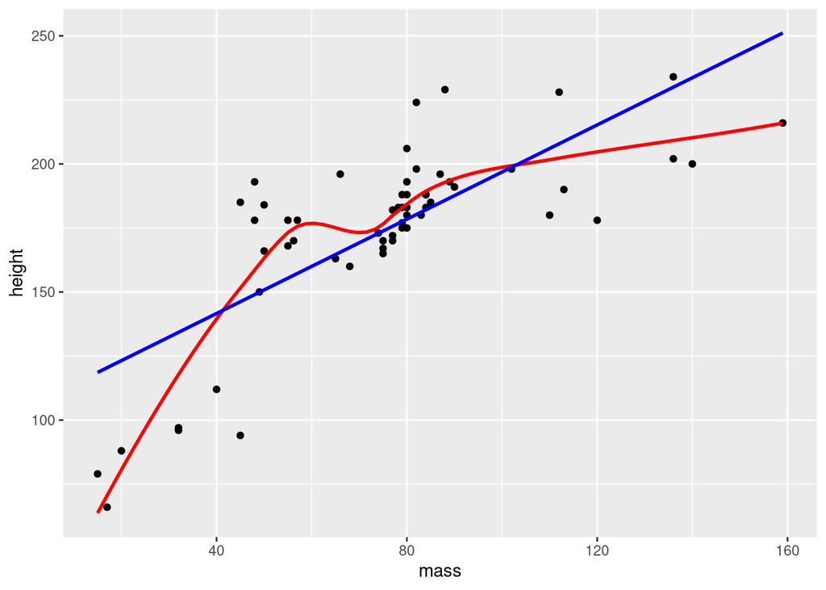

```r
linearity_check <- function(df, x, y) {
  df |>
    ggplot(aes(x = {{ x }}, y = {{ y }})) +
    geom_point() +
    geom_smooth(
      method = "loess",
      formula = y ~ x,
      color = "red",
      se = FALSE
    ) +
    geom_smooth(
      method = "lm",
      formula = y ~ x,
      color = "blue",
      se = FALSE
    )
}

starwars |>
  filter(mass < 1000) |>
  linearity_check(mass, height)
```

Example using a function to generate a plot for a large dataset where overplotting is a problem:

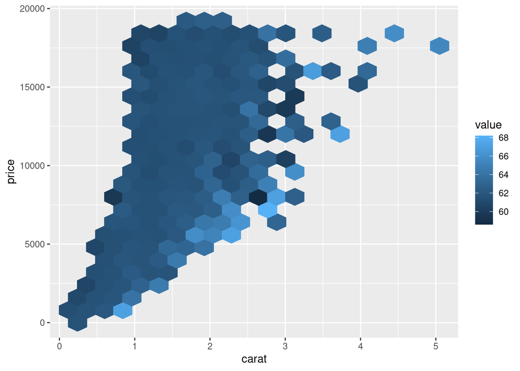

```r
hex_plot <- function(df, x, y, z, bins = 20, fun = "mean") {
  df |>
    ggplot(aes(x = {{ x }}, y = {{ y }}, z = {{ z }})) +
    stat_summary_hex(
      aes(color = after_scale(fill)), # make border color same as fill
      bins = bins,
      fun = fun
    )
}

diamonds |>  hex_plot(carat, price, depth)
```

### Combining with other tidyverse

A function to plot a sorted bar chart:

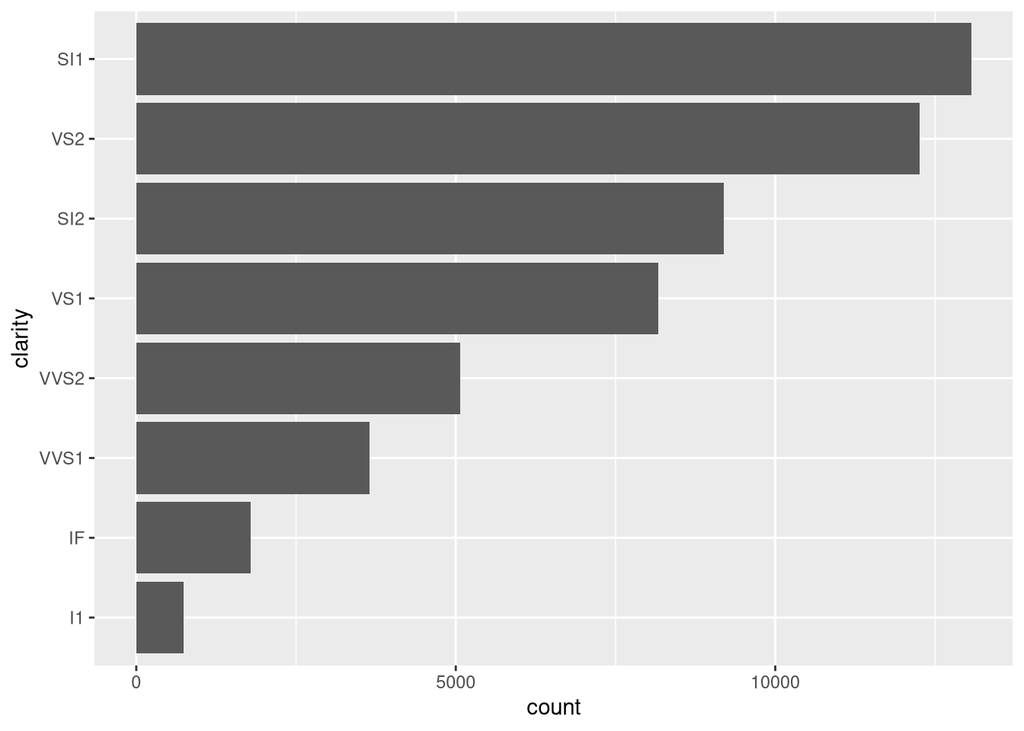

```r
sorted_bars <- function(df, var) {
  df |>
    mutate({{ var }} := fct_rev(fct_infreq({{ var }}))) |>
    ggplot(aes(y = {{ var }})) +
    geom_bar()
}

diamonds |> sorted_bars(clarity)
```

Note: the operator `:=`, commonly referred to as the “walrus operator” was used in the example to generate the variable name based on user-supplied data. This is necessary because the common behavior in R is to have only literal names on the left of the `=` operator. The walrus operator is a workaround solution to this problem.

Another example using functions to make it easier to draw a bar plot just for a subset of the data:

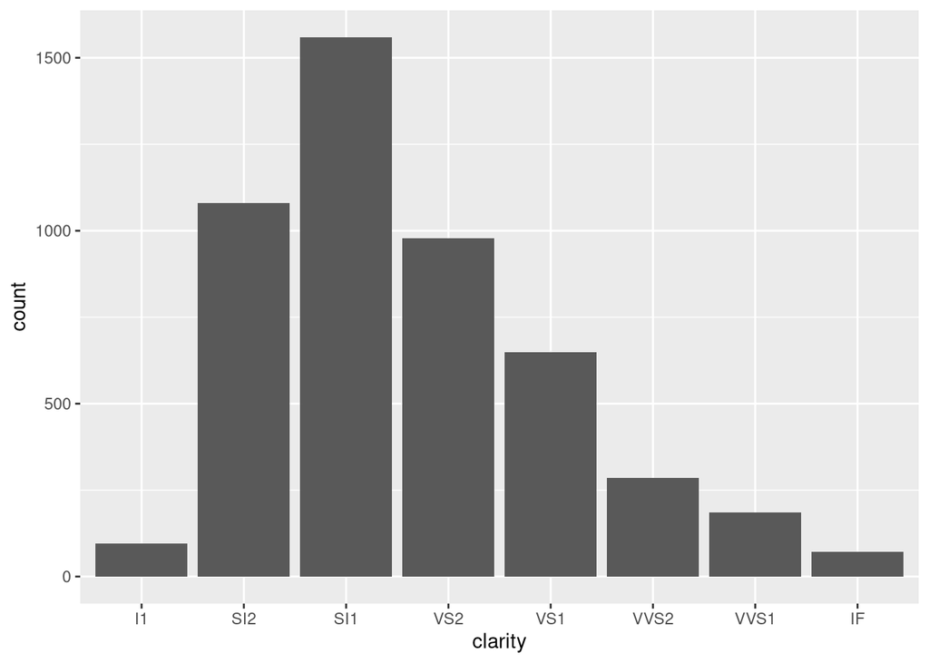

```r
conditional_bars <- function(df, condition, var) {
  df |>
    filter({{ condition }}) |>
    ggplot(aes(x = {{ var }})) +
    geom_bar()
}

diamonds |> conditional_bars(cut == "Good", clarity)
```

### Labeling

Using `rlang::englue()` to customize plot labels – this function works in a similar way to how Python’s f-strings are used in plot labels.

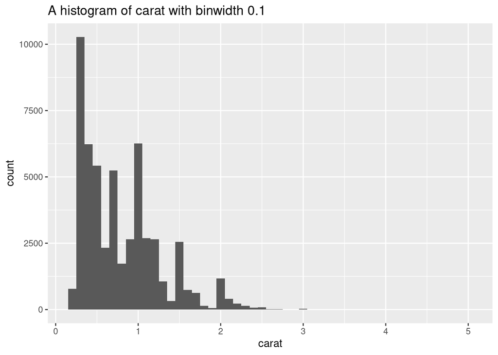

```r
histogram <- function(df, var, binwidth) {
  label <- rlang::englue("A histogram of {{var}} with binwidth {{binwidth}}")
  df |>
    ggplot(aes(x = {{ var }})) +
    geom_histogram(binwidth = binwidth) +
    labs(title = label)
}

diamonds |> histogram(carat, 0.1)
```

### Exercises

Build up a rich plotting function by incrementally implementing each of the steps below:

1. Draw a scatterplot given dataset and `x` and `y` variables.
2. Add a line of best fit (i.e. a linear modwel with no standard errors).
3. Add a title.

## Style

General guidelines:  
- The name of the function should clearly describe what the function does.  
- Function names are generally verbs (except when they compute some very well-known nouns like `mean()`, or property of an object, etc.).  
- Argument names are generally nouns.  
- Put one space before the brackets.  
- Indent the body by two spaces.  
- Put an extra space before and after the variable name inside the embracing brackets (`{{}}`).